# toyData

Autogenerated data summary from dataMaid

2018-04-11 01:01:56

# Data report overview

The dataset examined has the following dimensions:

| Feature | Result |
| --- | --- |
| Number of observations | 15 |
| Number of variables | 6 |

- Only variables that were deemed potentially problematic are included in this summary.

### Checks performed

The following variable checks were performed, depending on the data type of each variable:

|  | character | factor | labelled | numeric | integer | logical | Date |
| --- | --- | --- | --- | --- | --- | --- | --- |
| Identify miscoded missing values | × | × | × | × | × |  | × |
| Identify prefixed and suffixed whitespace | × | × | × |  |  |  |  |
| Identify levels with < 6 obs. | × | × | × |  |  |  |  |
| Identify case issues | × | × | × |  |  |  |  |
| Identify misclassified numeric or integer variables | × | × | × |  |  |  |  |
| Identify outliers |  |  |  | × | × |  | × |

Please note that all numerical values in the following have been rounded to 2 decimals.

# Summary table

|  | Variable class | # unique values | Missing observations | Any problems? |
| --- | --- | --- | --- | --- |
| pill | factor | 3 | 13.33 % | × |
| events | numeric | 9 | 20.00 % | × |
| region | factor | 7 | 0.00 % | × |
| change | numeric | 15 | 0.00 % | × |
| id | factor | 15 | 0.00 % | × |
| spotifysong | factor | 1 | 0.00 % | × |

# Variable list

## pill

| Feature | Result |
| --- | --- |
| Variable type | factor |
| Number of missing obs. | 2 (13.33 %) |
| Number of unique values | 2 |
| Mode | “red” |

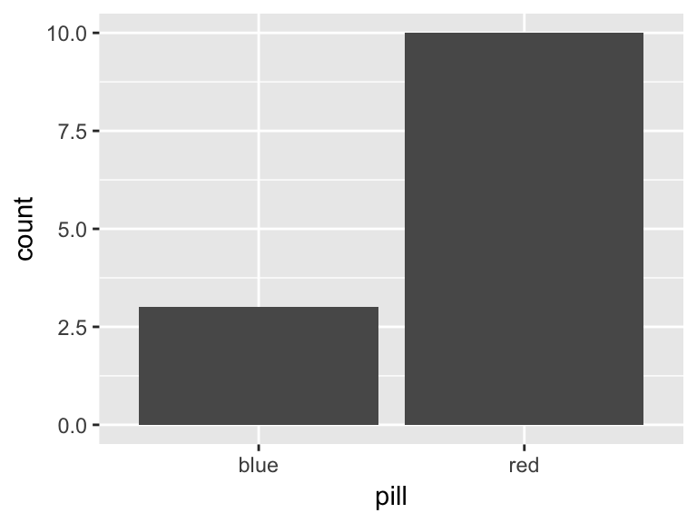

- Note that the following levels have at most five observations: "blue".

## events

| Feature | Result |
| --- | --- |
| Variable type | numeric |
| Number of missing obs. | 3 (20 %) |
| Number of unique values | 8 |
| Median | 4.5 |
| 1st and 3rd quartiles | 1.75; 6 |
| Min. and max. | 1; 999 |

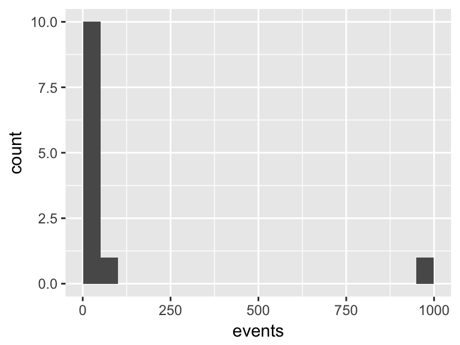

- The following suspected missing value codes enter as regular values: "999", "NaN".
- Note that the following possible outlier values were detected: "82", "999".

## region

| Feature | Result |
| --- | --- |
| Variable type | factor |
| Number of missing obs. | 0 (0 %) |
| Number of unique values | 7 |
| Mode | “a” |

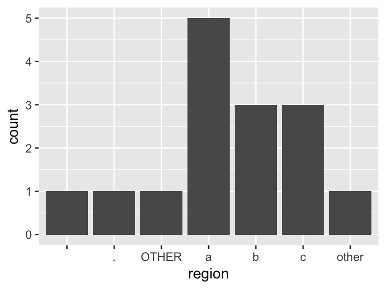

- The following suspected missing value codes enter as regular values: " ", ".".
- The following values appear with prefixed or suffixed white space: " ".
- Note that the following levels have at most five observations: " ", "." (5 additional values omitted).
- Note that there might be case problems with the following levels: "OTHER", "other".

## change

| Feature | Result |
| --- | --- |
| Variable type | numeric |
| Number of missing obs. | 0 (0 %) |
| Number of unique values | 15 |
| Median | 0.33 |
| 1st and 3rd quartiles | -0.62; 0.66 |
| Min. and max. | -2.21; 1.6 |

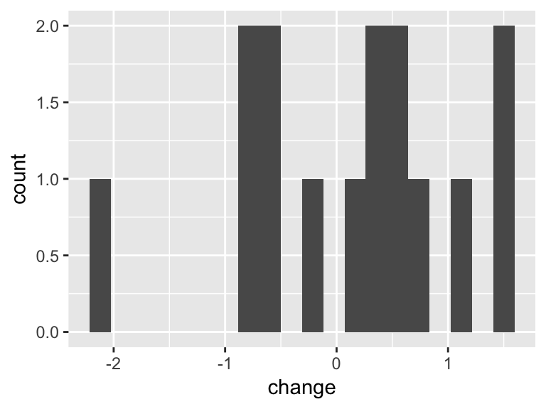

- Note that the following possible outlier values were detected: "1.12", "1.51" (1 additional values omitted).

## id

- The variable is a key (distinct values for each observation).

## spotifysong

- The variable only takes one (non-missing) value: "Irrelevant". The variable contains 0 % missing observations.

Report generation information:

- Created by Claus Thorn Ekstrøm (username: `cld189`).
- Report creation time: Wed Apr 11 2018 01:01:56
- Report Was run from directory: `/Users/cld189/ku/R/cleanR/latex`
- dataMaid v1.1.0 [Pkg: 2018-03-02 from local (ekstroem/dataMaid@NA)]
- R version 3.4.4 (2018-03-15).
- Platform: x86_64-apple-darwin15.6.0 (64-bit)(macOS High Sierra 10.13.3).
- Function call: `makeDataReport(data = toyData, output = "html", onlyProblematic = TRUE, replace = TRUE, maxProbVals = 2)`